# Praca domowa 2

Filip Łabuś

## Dane

Dane wykorzystane w Pracy domowej 2 dotyczą wyników egzaminów z 3 umiejętności: czytania, pisania i operacji matematycznych. Dodatkowo dostępne są podstawowe informacje o studentach i ich rodzicach. Opis wszystkich kolumn znajduje się również w pliku `README.md`.

| Zmienna | Opis |
| --- | --- |
| **gender** | płeć |
| **race.ethnicity** | pochodzenie etniczne |
| **parental.level.of.education** | wykształcenie rodziców |
| **lunch** | jaki obiad jedli uczniowie w dniu egzaminu |
| **test.preparation.course** | czy uczeń odbył kurs przygotowujący |
| **math.score** | wynik egzaminu z matematyki |
| **reading.score** | wynik egzaminu z czytania |
| **writing.score** | wynik egzaminu z pisania |

## Zadanie 1

Jak wyglądają rozkłady wyników uczniów z trzech przedmiotów (matematyka, czytanie, pisanie)?

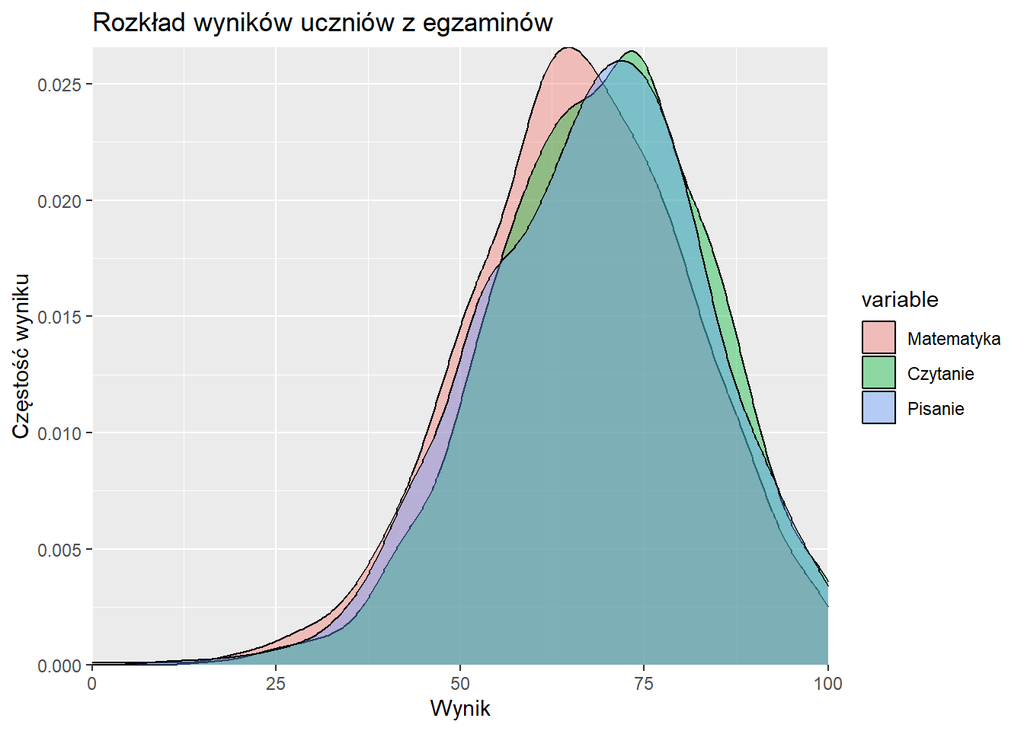

```r
pivot_longer(df, cols =c("math.score", "reading.score", "writing.score"), names_to = "variable", values_to = "value") %>%
  ggplot(aes(x = value, fill = variable))+
  geom_density(alpha = 0.4)+
  scale_fill_discrete(labels = c(
    "math.score" = "Matematyka",
    "reading.score" = "Czytanie",
    "writing.score" = "Pisanie"))+
  labs(title = "Rozkład wyników uczniów z egzaminów",
       x = "Wynik",
       y = "Częstość wyniku")+
  scale_x_continuous(expand = c(0,0))+
  scale_y_continuous(expand = c(0,0))
```

**Komentarz:** **Najgorsze wyniki są z egzaminu z Matematyki. Egzaminy z czytania oraz pisania wypadły bardzo podobnie. Niemniej rożnice między egzaminami są niewielkie.**

## Zadanie 2

Czy istnieje zauważalna różnica w wynikach między uczniami i uczennicami?

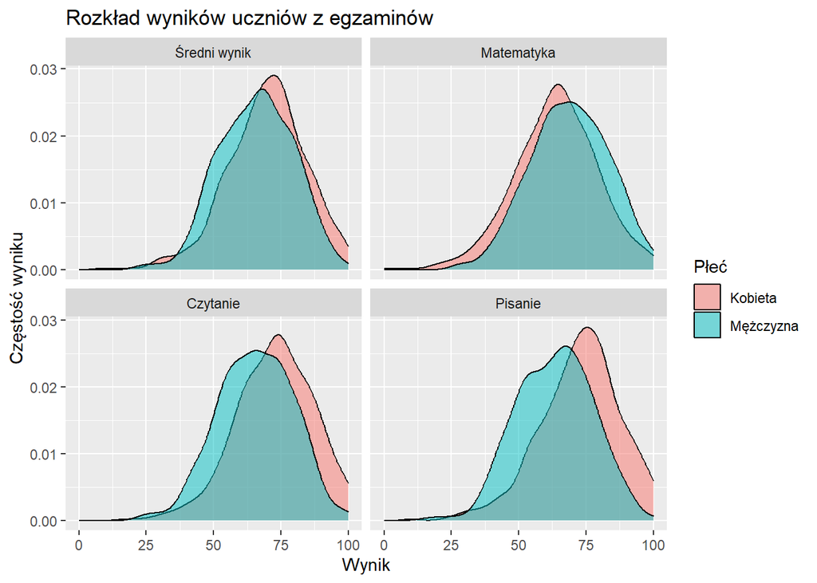

```r
df %>%
  pivot_longer(cols = c(math.score, reading.score, writing.score, avg.score),
               names_to = "exam", values_to = "value") %>%
  ggplot(aes(x = value, fill = gender)) +
  geom_density(alpha = 0.5) +
  facet_wrap(~ exam, nrow = 2, labeller = labeller(exam = c(
        "math.score" = "Matematyka",
        "reading.score" = "Czytanie",
        "writing.score" = "Pisanie",
        "avg.score" = "Średni wynik")))+
  scale_fill_discrete(labels = c("female" = "Kobieta", "male" = "Mężczyzna"))+
  labs(title = "Rozkład wyników uczniów z egzaminów",
       fill = "Płeć",
       x = "Wynik",
       y = "Częstość wyniku")
```

**Komentarz:** **Kobiety lepiej sobie ogólnie poradziły z egzaminami. Rozpatrując poszczególne przedmioty lepiej poradziły sobie z egzaminami z czytania oraz pisania. Egzamin z Matematyki jednak lepiej wyszedł mężczyznom. Możemy zaobserować, że rozkład wyników mężczyzn jest “szerszy”, czyli rozpiętość osiąganych wyników jest większa**

## Zadanie 3

Czy uczniowie, którzy ukończyli kurs przygotowawczy, osiągają lepsze wyniki niż pozostali?

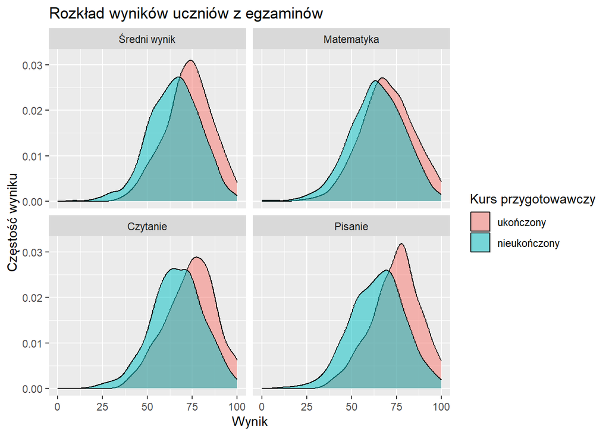

```r
df %>%
  pivot_longer(cols = c(math.score, reading.score, writing.score, avg.score),
               names_to = "exam", values_to = "value") %>%
  ggplot(aes(x = value, fill = test.preparation.course)) +
  geom_density(alpha = 0.5) +
  facet_wrap(~ exam, nrow = 2, labeller = labeller(exam = c(
        "math.score" = "Matematyka",
        "reading.score" = "Czytanie",
        "writing.score" = "Pisanie",
        "avg.score" = "Średni wynik")))+
  scale_fill_discrete(labels = c("completed" = "ukończony", "none" = "nieukończony"))+
  labs(title = "Rozkład wyników uczniów z egzaminów",
       fill = "Kurs przygotowawczy",
       x = "Wynik",
       y = "Częstość wyniku")
```

**Komentarz:** **W każdym wypadku jest zauważalna poprawa wyników egzaminu po ukończeniu kursu. Najmniejsza poprawa jest widoczna przy egzaminie z Matematyki. Przy egzaminie z pisania widzimy “zawężenie się” rozkładu wyników, oznacza to, że więcej uczniów uzyskało wynik bliski średniemu (około 77%) niż bez ukończenia kursu.**

## Zadanie 4

Jaki jest związek między poziomem wykształcenia rodziców a średnimi wynikami uczniów?

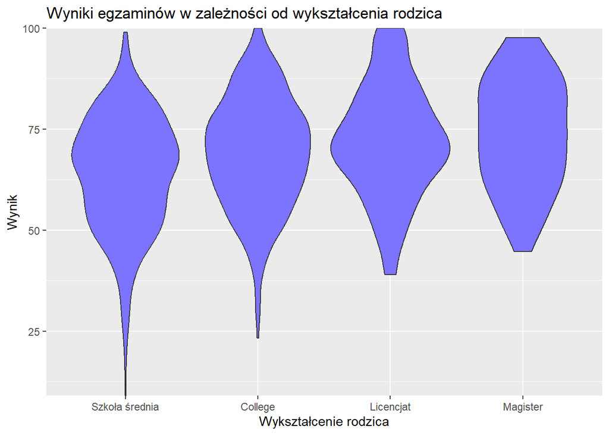

```r
df %>% mutate(parental.level.of.education = ifelse(parental.level.of.education == "some high school", "high school", parental.level.of.education)) %>%
  mutate(parental.level.of.education = ifelse(parental.level.of.education == "some college", "associate's degree", parental.level.of.education)) %>%
  mutate(parental.level.of.education = factor(parental.level.of.education,
  levels = c("high school", "associate's degree", "bachelor's degree", "master's degree"),
  labels = c("Szkoła średnia", "College", "Licencjat", "Magister"))) -> df_new
  df_new %>% ggplot(aes(y = avg.score, x = parental.level.of.education))+
  geom_violin(fill = "#7c73ff")+
  labs(title = "Wyniki egzaminów w zależności od wykształcenia rodzica",
       x = "Wykształcenie rodzica",
       y = "Wynik")+
  scale_y_continuous(expand = c(0,0))
```

**Komentarz:** **Połączyłem stopnie wykształcenia “high school” z “some high school” a także “some college” z “associate’s degree” z powodu ich równoważności. Widzimy, że najniższe wartości wyników osiąganych na egzaminie były osiągane przez dzieci osób z wykształceniem średnim. Średni wynik w każdej grupie był zbliżony, jednakże na podstawie rozkładu wyników możemy twierdzić,że największy udział wysokich wyników mają dzieci ludzi z wykształceniem bachelor(licencjat/inżynier) lub master(magister). Co ciekawe żadne z dzieci magistrów nie uzyskało maksymalnego wyniku ze wszystkich trzech egzaminów**

## Zadanie 5

Czy płeć i wykształcenie rodzica wpływa na wynik z matematyki?

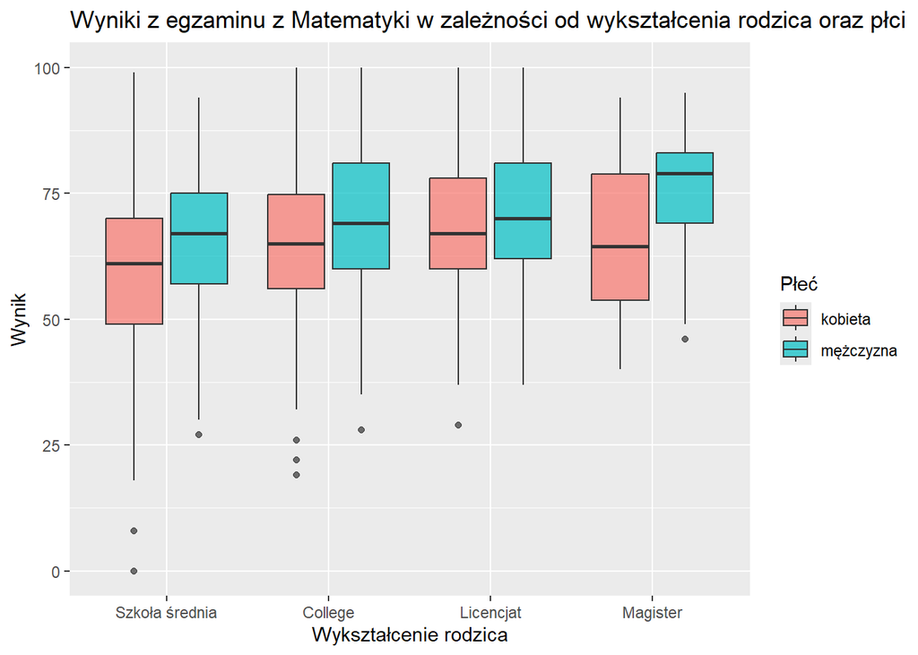

```r
ggplot(df_new, aes(x = parental.level.of.education, y = math.score, fill = gender))+
  geom_boxplot(position = position_dodge(width = 0.8), width = 0.7, alpha = 0.7)+
  labs(x = "Wykształcenie rodzica", y = "Wynik", fill = "Płeć",
       title = "Wyniki z egzaminu z Matematyki w zależności od wykształcenia rodzica oraz płci")+
  scale_fill_discrete(labels = c("female" = "kobieta", "male" = "mężczyzna"))
```

## Zadanie 6

Czy istnieje zależność między wynikami z matematyki a wynikami z czytania lub pisania?

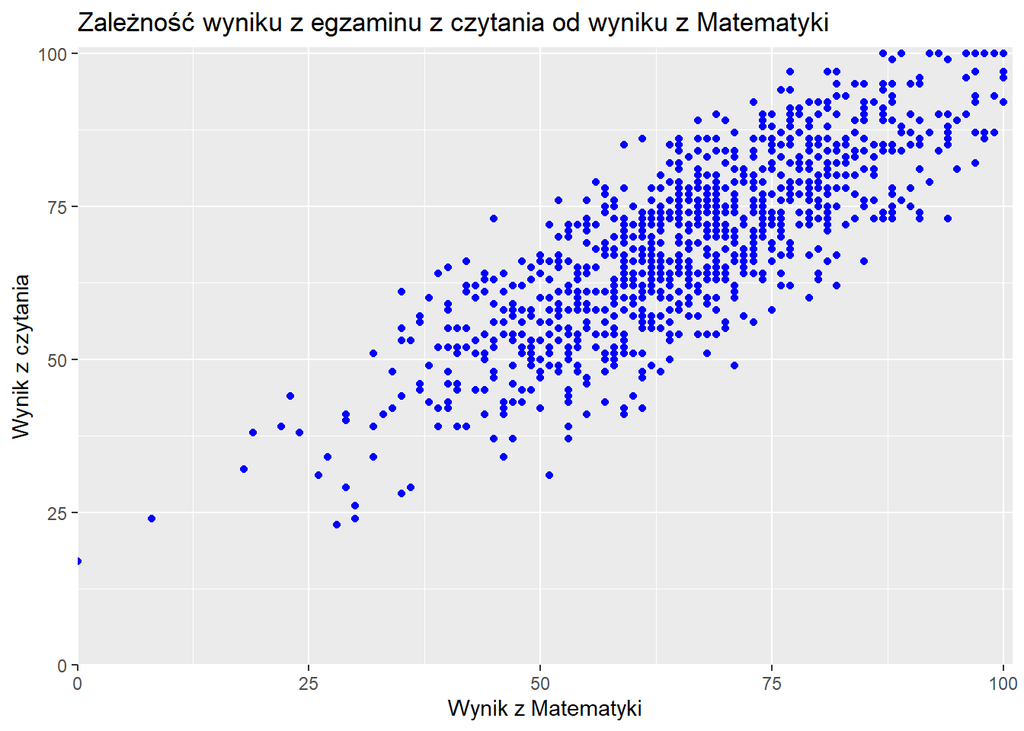

```r
df %>% ggplot(aes(x = math.score, y = reading.score))+
  geom_point(color = "blue") +
  labs(title = "Zależność wyniku z egzaminu z czytania od wyniku z Matematyki",
       x = "Wynik z Matematyki",
       y = "Wynik z czytania")+
  scale_y_continuous(expand = c(0,0), limits = c(0,101))+
  scale_x_continuous(expand = c(0,0), limits = c(0,101))
```

**Komentarz:** **Na wykresie przedstawiono wyniki z testu z czytania w zależności od wyniku tesu z Matematyki. Jak widzimy możemy przewidywać, że uzyskanie wyższego wyniku z Matematyki sugeruje uzyskanie wyższego wyniku z czytania. Do podobnych wniosków możemy również dojść robiąc analizując egzamin z pisania.**